# Biostat 203B Homework 2

Due Feb 6 @ 11:59PM

Kuan-Hung (Peter) Yeh (UID:705669455)

```r
knitr::opts_chunk$set(echo = TRUE, cache = TRUE, cache.lazy = FALSE)
library(tidyverse)
library(data.table)
library(lubridate)
```

```r
os <- sessionInfo()$running
if (str_detect(os, "Linux")) {
  mimic_path <- "/mnt/mimiciv/1.0"
} else if (str_detect(os, "macOS")) {
  mimic_path <- "/Users/huazhou/Documents/Box Sync/MIMIC/mimic-iv-1.0"
}
```

In this exercise, we use tidyverse (ggpot2, dplyr, etc) to explore the [MIMIC-IV](https://mimic.mit.edu/docs/iv/) data introduced in [homework 1](https://ucla-biostat-203b.github.io/2022winter/hw/hw1/hw1.html) and to build a cohort of ICU stays.

```r
# tree -s -L 2 /Users/huazhou/Documents/Box\ Sync/MIMIC/mimic-iv-1.0
system(str_c("tree -s -L 2 ", shQuote(mimic_path)), intern = TRUE)
```

```
##  [1] "/mnt/mimiciv/1.0"
##  [2] "├── [       4096]  core"
##  [3] "│   ├── [   17208966]  admissions.csv.gz"
##  [4] "│   ├── [        606]  index.html"
##  [5] "│   ├── [    2955582]  patients.csv.gz"
##  [6] "│   └── [   53014503]  transfers.csv.gz"
##  [7] "├── [       4096]  hosp"
##  [8] "│   ├── [     430049]  d_hcpcs.csv.gz"
##  [9] "│   ├── [   29531152]  diagnoses_icd.csv.gz"
## [10] "│   ├── [     863239]  d_icd_diagnoses.csv.gz"
## [11] "│   ├── [     579998]  d_icd_procedures.csv.gz"
## [12] "│   ├── [      14898]  d_labitems.csv.gz"
## [13] "│   ├── [   11684062]  drgcodes.csv.gz"
## [14] "│   ├── [  515763427]  emar.csv.gz"
## [15] "│   ├── [  476252563]  emar_detail.csv.gz"
```

[output cut: 26 more lines]

## Q1. `read.csv` (base R) vs `read_csv` (tidyverse) vs `fread` (data.table)

There are quite a few utilities in R for reading plain text data files. Let us test the speed of reading a moderate sized compressed csv file, `admissions.csv.gz`, by three programs: `read.csv` in base R, `read_csv` in tidyverse, and `fread` in the popular data.table package.

```r
#`read.csv` in base R
system.time(read.csv("/mnt/mimiciv/1.0/core/admissions.csv.gz"))
```

```
##    user  system elapsed
##  42.642   0.246  42.898
```

```r
#`read_csv` in tidyverse
system.time(read_csv("/mnt/mimiciv/1.0/core/admissions.csv.gz"))
```

```
##    user  system elapsed
##   3.551   0.272   2.112
```

```r
# `fread` in the popular data.table package.
system.time(fread("/mnt/mimiciv/1.0/core/admissions.csv.gz"))
```

```
##    user  system elapsed
##   1.471   0.096   0.905
```

Which function is fastest? Is there difference in the (default) parsed data types? (Hint: R function `system.time` measures run times.)

**Solution:**

```r
#`read.csv` in base R
read1 <- read.csv("/mnt/mimiciv/1.0/core/admissions.csv.gz")
str(read1)
```

```
## 'data.frame':    523740 obs. of  15 variables:
##  $ subject_id          : int  14679932 15585972 11989120 17817079 15078341 19124609 17301855 17991012 16865435 13693648 ...
##  $ hadm_id             : int  21038362 24941086 21965160 24709883 23272159 20517215 29732723 24298836 23216961 21640725 ...
##  $ admittime           : Factor w/ 514435 levels "2105-10-04 17:26:00",..: 162283 62357 210124 330971 56261 351331 166789 430755 456181 3345 ...
##  $ dischtime           : Factor w/ 507789 levels "2105-10-12 11:11:00",..: 160158 61694 207314 326516 55632 346651 164592 424886 449948 3316 ...
##  $ deathtime           : Factor w/ 9337 levels "","2110-01-25 09:40:00",..: 1 1 1 1 1 1 1 1 1 1 ...
##  $ admission_type      : Factor w/ 9 levels "AMBULATORY OBSERVATION",..: 4 4 4 4 4 4 4 4 4 4 ...
##  $ admission_location  : Factor w/ 12 levels "","AMBULATORY SURGERY TRANSFER",..: 1 1 1 1 1 1 1 1 1 1 ...
##  $ discharge_location  : Factor w/ 14 levels "","ACUTE HOSPITAL",..: 8 8 8 8 8 8 8 8 8 8 ...
##  $ insurance           : Factor w/ 3 levels "Medicaid","Medicare",..: 3 3 3 3 3 3 3 3 3 3 ...
##  $ language            : Factor w/ 2 levels "?","ENGLISH": 2 2 2 2 2 2 2 2 2 2 ...
##  $ marital_status      : Factor w/ 5 levels "","DIVORCED",..: 4 1 1 1 1 1 1 1 1 1 ...
##  $ ethnicity           : Factor w/ 8 levels "AMERICAN INDIAN/ALASKA NATIVE",..: 7 8 7 5 3 7 8 8 8 8 ...
##  $ edregtime           : Factor w/ 310256 levels "","2109-08-31 02:46:00",..: 1 1 1 1 1 1 1 1 1 1 ...
##  $ edouttime           : Factor w/ 310322 levels "","2109-08-31 07:51:00",..: 1 1 1 1 1 1 1 1 1 1 ...
##  $ hospital_expire_flag: int  0 0 0 0 0 0 0 0 0 0 ...
```

```r
#`read_csv` in tidyverse
read2 <- read_csv("/mnt/mimiciv/1.0/core/admissions.csv.gz")
str(read2)
```

```
## spec_tbl_df [523,740 × 15] (S3: spec_tbl_df/tbl_df/tbl/data.frame)
##  $ subject_id          : num [1:523740] 14679932 15585972 11989120 17817079 15078341 ...
##  $ hadm_id             : num [1:523740] 21038362 24941086 21965160 24709883 23272159 ...
##  $ admittime           : POSIXct[1:523740], format: "2139-09-26 14:16:00" "2123-10-07 23:56:00" ...
##  $ dischtime           : POSIXct[1:523740], format: "2139-09-28 11:30:00" "2123-10-12 11:22:00" ...
##  $ deathtime           : POSIXct[1:523740], format: NA NA ...
##  $ admission_type      : chr [1:523740] "ELECTIVE" "ELECTIVE" "ELECTIVE" "ELECTIVE" ...
##  $ admission_location  : chr [1:523740] NA NA NA NA ...
##  $ discharge_location  : chr [1:523740] "HOME" "HOME" "HOME" "HOME" ...
##  $ insurance           : chr [1:523740] "Other" "Other" "Other" "Other" ...
##  $ language            : chr [1:523740] "ENGLISH" "ENGLISH" "ENGLISH" "ENGLISH" ...
##  $ marital_status      : chr [1:523740] "SINGLE" NA NA NA ...
##  $ ethnicity           : chr [1:523740] "UNKNOWN" "WHITE" "UNKNOWN" "OTHER" ...
##  $ edregtime           : POSIXct[1:523740], format: NA NA ...
##  $ edouttime           : POSIXct[1:523740], format: NA NA ...
##  $ hospital_expire_flag: num [1:523740] 0 0 0 0 0 0 0 0 0 0 ...
##  - attr(*, "spec")=
##   .. cols(
##   ..   subject_id = col_double(),
##   ..   hadm_id = col_double(),
##   ..   admittime = col_datetime(format = ""),
##   ..   dischtime = col_datetime(format = ""),
##   ..   deathtime = col_datetime(format = ""),
##   ..   admission_type = col_character(),
##   ..   admission_location = col_character(),
##   ..   discharge_location = col_character(),
##   ..   insurance = col_character(),
##   ..   language = col_character(),
##   ..   marital_status = col_character(),
##   ..   ethnicity = col_character(),
##   ..   edregtime = col_datetime(format = ""),
##   ..   edouttime = col_datetime(format = ""),
##   ..   hospital_expire_flag = col_double()
##   .. )
##  - attr(*, "problems")=<externalptr>
```

```r
# `fread` in the popular data.table package.
read3 <- fread("/mnt/mimiciv/1.0/core/admissions.csv.gz")
str(read3)
```

```
## Classes 'data.table' and 'data.frame':   523740 obs. of  15 variables:
##  $ subject_id          : int  14679932 15585972 11989120 17817079 15078341 19124609 17301855 17991012 16865435 13693648 ...
##  $ hadm_id             : int  21038362 24941086 21965160 24709883 23272159 20517215 29732723 24298836 23216961 21640725 ...
##  $ admittime           : POSIXct, format: "2139-09-26 14:16:00" "2123-10-07 23:56:00" ...
##  $ dischtime           : POSIXct, format: "2139-09-28 11:30:00" "2123-10-12 11:22:00" ...
##  $ deathtime           : POSIXct, format: NA NA ...
##  $ admission_type      : chr  "ELECTIVE" "ELECTIVE" "ELECTIVE" "ELECTIVE" ...
##  $ admission_location  : chr  "" "" "" "" ...
##  $ discharge_location  : chr  "HOME" "HOME" "HOME" "HOME" ...
##  $ insurance           : chr  "Other" "Other" "Other" "Other" ...
##  $ language            : chr  "ENGLISH" "ENGLISH" "ENGLISH" "ENGLISH" ...
##  $ marital_status      : chr  "SINGLE" "" "" "" ...
##  $ ethnicity           : chr  "UNKNOWN" "WHITE" "UNKNOWN" "OTHER" ...
##  $ edregtime           : POSIXct, format: NA NA ...
##  $ edouttime           : POSIXct, format: NA NA ...
##  $ hospital_expire_flag: int  0 0 0 0 0 0 0 0 0 0 ...
##  - attr(*, ".internal.selfref")=<externalptr>
```

For later questions, we stick to the tidyverse.

## Q2. ICU stays

`icustays.csv.gz` (https://mimic.mit.edu/docs/iv/modules/icu/icustays/) contains data about Intensive Care Units (ICU) stays. The first 10 lines are

```r
system(
  str_c(
    "zcat < ",
    shQuote(str_c(mimic_path, "/icu/icustays.csv.gz")),
    " | head"
    ),
  intern = TRUE
)
```

```
##  [1] "subject_id,hadm_id,stay_id,first_careunit,last_careunit,intime,outtime,los"
##  [2] "17867402,24528534,31793211,Trauma SICU (TSICU),Trauma SICU (TSICU),2154-03-03 04:11:00,2154-03-04 18:16:56,1.5874537037037035"
##  [3] "14435996,28960964,31983544,Trauma SICU (TSICU),Trauma SICU (TSICU),2150-06-19 17:57:00,2150-06-22 18:33:54,3.025625"
##  [4] "17609946,27385897,33183475,Trauma SICU (TSICU),Trauma SICU (TSICU),2138-02-05 18:54:00,2138-02-15 12:42:05,9.741724537037038"
##  [5] "18966770,23483021,34131444,Trauma SICU (TSICU),Trauma SICU (TSICU),2123-10-25 10:35:00,2123-10-25 18:59:47,0.35054398148148147"
##  [6] "12776735,20817525,34547665,Neuro Stepdown,Neuro Stepdown,2200-07-12 00:33:00,2200-07-13 16:44:40,1.6747685185185184"
##  [7] "10215159,24283593,34569476,Trauma SICU (TSICU),Trauma SICU (TSICU),2124-09-20 15:05:29,2124-09-21 22:06:58,1.2926967592592593"
##  [8] "14489052,26516390,35056286,Trauma SICU (TSICU),Trauma SICU (TSICU),2118-10-26 10:33:56,2118-10-26 20:28:10,0.4126620370370371"
##  [9] "15914763,28906020,36909804,Trauma SICU (TSICU),Trauma SICU (TSICU),2176-12-14 12:00:00,2176-12-17 11:47:01,2.9909837962962964"
## [10] "16256226,20013290,39289362,Neuro Stepdown,Neuro Stepdown,2150-12-20 16:09:08,2150-12-21 14:58:40,0.9510648148148149"
```

1. Import `icustatys.csv.gz` as a tibble `icustays_tble`.

**Solution:**

```r
#`read_csv` in tidyverse to import icustatys.csv.gz
icustays_tble <- read_csv("/mnt/mimiciv/1.0/icu/icustays.csv.gz")
head(icustays_tble)
```

```
## # A tibble: 6 × 8
##   subject_id  hadm_id  stay_id first_careunit  last_careunit intime
##        <dbl>    <dbl>    <dbl> <chr>           <chr>         <dttm>
## 1   17867402 24528534 31793211 Trauma SICU (T… Trauma SICU … 2154-03-03 04:11:00
## 2   14435996 28960964 31983544 Trauma SICU (T… Trauma SICU … 2150-06-19 17:57:00
## 3   17609946 27385897 33183475 Trauma SICU (T… Trauma SICU … 2138-02-05 18:54:00
## 4   18966770 23483021 34131444 Trauma SICU (T… Trauma SICU … 2123-10-25 10:35:00
## 5   12776735 20817525 34547665 Neuro Stepdown  Neuro Stepdo… 2200-07-12 00:33:00
## 6   10215159 24283593 34569476 Trauma SICU (T… Trauma SICU … 2124-09-20 15:05:29
## # … with 2 more variables: outtime <dttm>, los <dbl>
```

2. How many unique `subject_id`? Can a `subject_id` have multiple ICU stays?

**Solution:**

```r
icustays_tble %>%
  distinct(subject_id) %>%
  nrow()
```

```
## [1] 53150
```

There are 53150 unique subject_id in icustays_tble. And, Yes, a subject id can have more than one ICU stays. From the result below, we can see that the maximum time of ICU stays is 37 times for subject is = 18358138.

```r
icustays_tble %>%
  group_by(subject_id) %>%
  summarise(n=n()) %>%
  arrange(desc(n)) %>%
  head()
```

```
## # A tibble: 6 × 2
##   subject_id     n
##        <dbl> <int>
## 1   18358138    37
## 2   12468016    33
## 3   17585185    33
## 4   13269859    30
## 5   18676703    26
## 6   11281568    25
```

3. For each `subject_id`, let’s only keep the first ICU stay in the tibble `icustays_tble`.

**Solution:**

From the result below, I checked the rows of this subset will be 53150, which make sense sine every unique patient had their first record when they transferred to ICU.

```r
icustays_tble <- icustays_tble %>%
                 group_by(subject_id) %>%
                 arrange(intime) %>%
                 filter(row_number()==1)
icustays_tble
```

```
## # A tibble: 53,150 × 8
## # Groups:   subject_id [53,150]
##    subject_id  hadm_id  stay_id first_careunit last_careunit intime
##         <dbl>    <dbl>    <dbl> <chr>          <chr>         <dttm>
##  1   18106347 24305596 30588857 Cardiac Vascu… Cardiac Vasc… 2110-01-11 10:16:06
##  2   17195991 23542772 38319097 Surgical Inte… Surgical Int… 2110-01-12 00:54:00
##  3   16284044 23864737 36817845 Cardiac Vascu… Cardiac Vasc… 2110-01-13 09:09:40
##  4   18122666 23883987 39753527 Medical/Surgi… Medical/Surg… 2110-01-14 07:22:00
##  5   18780420 28977824 32140208 Neuro Surgica… Neuro Surgic… 2110-01-17 00:28:00
##  6   15092543 28768907 38339174 Neuro Interme… Neuro Interm… 2110-01-17 22:49:13
##  7   13201095 28453791 39953418 Coronary Care… Coronary Car… 2110-01-18 14:46:27
##  8   12770182 20446666 34901199 Medical Inten… Medical Inte… 2110-01-18 17:47:47
##  9   12224263 23294937 37546608 Trauma SICU (… Trauma SICU … 2110-01-20 14:01:00
## 10   19564586 22461053 37310703 Coronary Care… Coronary Car… 2110-01-20 21:06:30
## # … with 53,140 more rows, and 2 more variables: outtime <dttm>, los <dbl>
```

## Q3. `admission` data

Information of the patients admitted into hospital is available in `admissions.csv.gz`. See https://mimic.mit.edu/docs/iv/modules/core/admissions/ for details of each field in this file. The first 10 lines are

```r
system(
  str_c(
    "zcat < ",
    shQuote(str_c(mimic_path, "/core/admissions.csv.gz")),
    " | head"
    ),
  intern = TRUE
)
```

```
##  [1] "subject_id,hadm_id,admittime,dischtime,deathtime,admission_type,admission_location,discharge_location,insurance,language,marital_status,ethnicity,edregtime,edouttime,hospital_expire_flag"
##  [2] "14679932,21038362,2139-09-26 14:16:00,2139-09-28 11:30:00,,ELECTIVE,,HOME,Other,ENGLISH,SINGLE,UNKNOWN,,,0"
##  [3] "15585972,24941086,2123-10-07 23:56:00,2123-10-12 11:22:00,,ELECTIVE,,HOME,Other,ENGLISH,,WHITE,,,0"
##  [4] "11989120,21965160,2147-01-14 09:00:00,2147-01-17 14:25:00,,ELECTIVE,,HOME,Other,ENGLISH,,UNKNOWN,,,0"
##  [5] "17817079,24709883,2165-12-27 17:33:00,2165-12-31 21:18:00,,ELECTIVE,,HOME,Other,ENGLISH,,OTHER,,,0"
##  [6] "15078341,23272159,2122-08-28 08:48:00,2122-08-30 12:32:00,,ELECTIVE,,HOME,Other,ENGLISH,,BLACK/AFRICAN AMERICAN,,,0"
##  [7] "19124609,20517215,2169-03-14 12:44:00,2169-03-20 19:15:00,,ELECTIVE,,HOME,Other,ENGLISH,,UNKNOWN,,,0"
##  [8] "17301855,29732723,2140-06-06 14:23:00,2140-06-08 14:25:00,,ELECTIVE,,HOME,Other,ENGLISH,,WHITE,,,0"
##  [9] "17991012,24298836,2181-07-10 20:28:00,2181-07-12 15:49:00,,ELECTIVE,,HOME,Other,ENGLISH,,WHITE,,,0"
## [10] "16865435,23216961,2185-07-19 02:12:00,2185-07-21 11:50:00,,ELECTIVE,,HOME,Other,ENGLISH,,WHITE,,,0"
```

1. Import `admissions.csv.gz` as a tibble `admissions_tble`.

**Solution:**

```r
admissions_tble <- read_csv("/mnt/mimiciv/1.0/core/admissions.csv.gz")
head(admissions_tble)
```

```
## # A tibble: 6 × 15
##   subject_id  hadm_id admittime           dischtime           deathtime
##        <dbl>    <dbl> <dttm>              <dttm>              <dttm>
## 1   14679932 21038362 2139-09-26 14:16:00 2139-09-28 11:30:00 NA
## 2   15585972 24941086 2123-10-07 23:56:00 2123-10-12 11:22:00 NA
## 3   11989120 21965160 2147-01-14 09:00:00 2147-01-17 14:25:00 NA
## 4   17817079 24709883 2165-12-27 17:33:00 2165-12-31 21:18:00 NA
## 5   15078341 23272159 2122-08-28 08:48:00 2122-08-30 12:32:00 NA
## 6   19124609 20517215 2169-03-14 12:44:00 2169-03-20 19:15:00 NA
## # … with 10 more variables: admission_type <chr>, admission_location <chr>,
## #   discharge_location <chr>, insurance <chr>, language <chr>,
## #   marital_status <chr>, ethnicity <chr>, edregtime <dttm>, edouttime <dttm>,
## #   hospital_expire_flag <dbl>
```

2. Let’s only keep the admissions that have a match in `icustays_tble` according to `subject_id` and `hadmi_id`.

**Solution:**

```r
ad_icu_combine <-
  admissions_tble %>%
  semi_join(icustays_tble, by = c("subject_id", "hadm_id"))
```

3. Summarize the following variables by graphics.

**Solution:**

- admission year

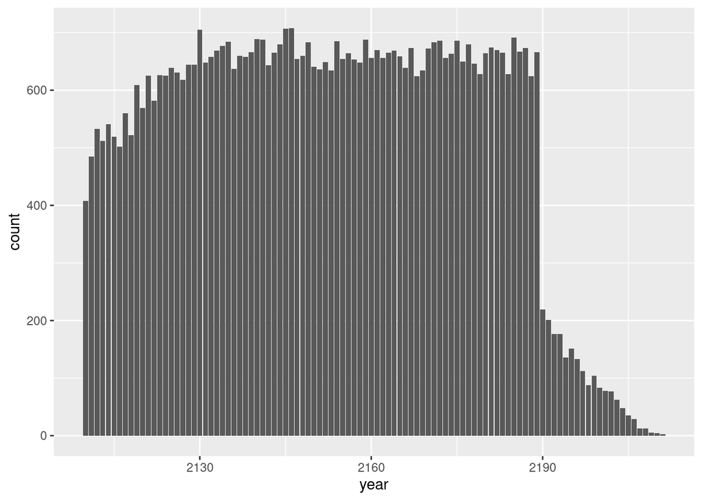

```r
#admission year
ad_icu_combine$admittime <- ymd_hms(ad_icu_combine$admittime)
ad_icu_combine %>%
  mutate(year = year(admittime), label = TRUE) %>%
  ggplot(aes(x = year)) +
  geom_bar()
```

- admission month

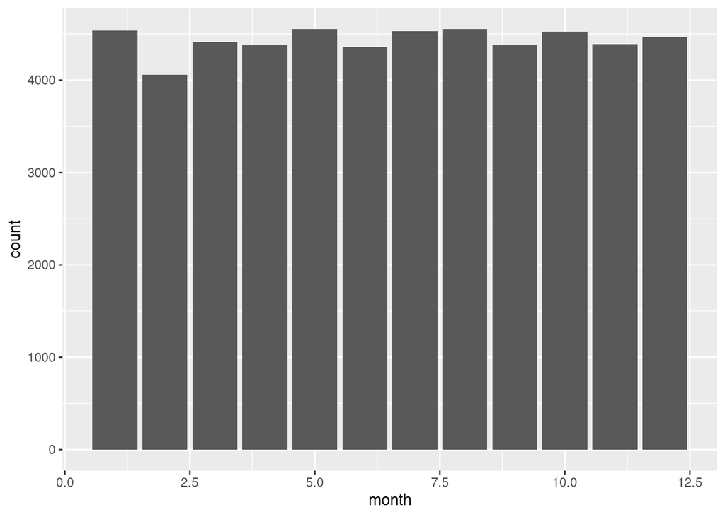

```r
#admission month
ad_icu_combine %>%
  mutate(month = month(admittime), label = TRUE) %>%
  ggplot(aes(x = month)) +
  geom_bar()
```

- admission month day

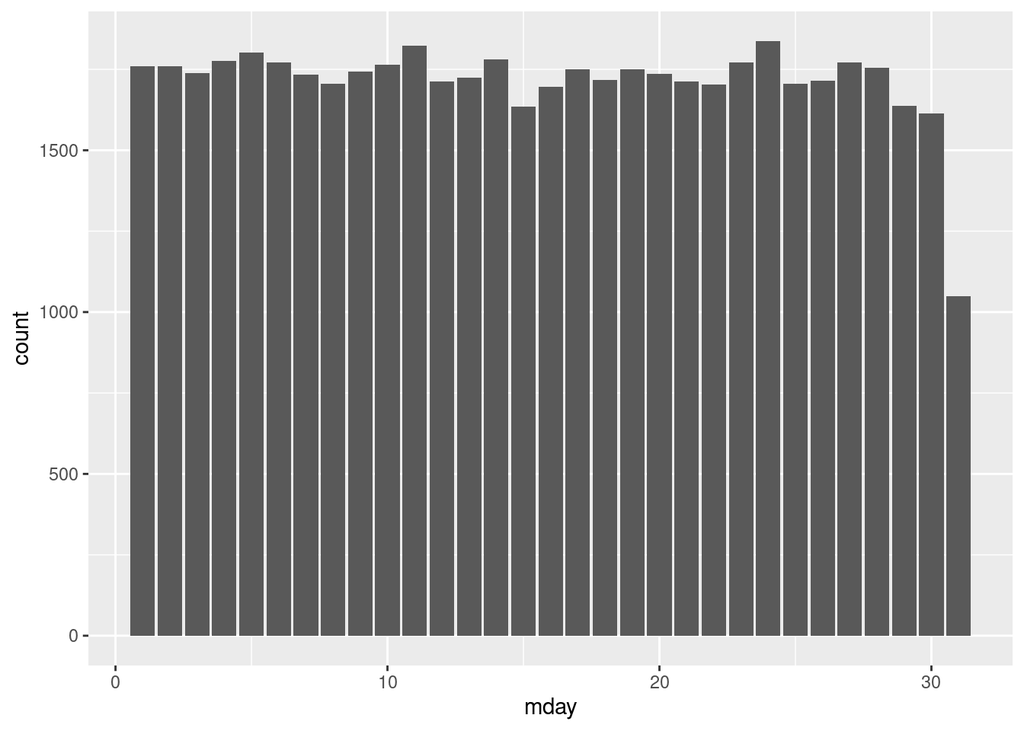

```r
#admission month day
ad_icu_combine %>%
  mutate(mday = mday(admittime), label = TRUE) %>%
  ggplot(aes(x = mday)) +
  geom_bar()
```

- admission week day

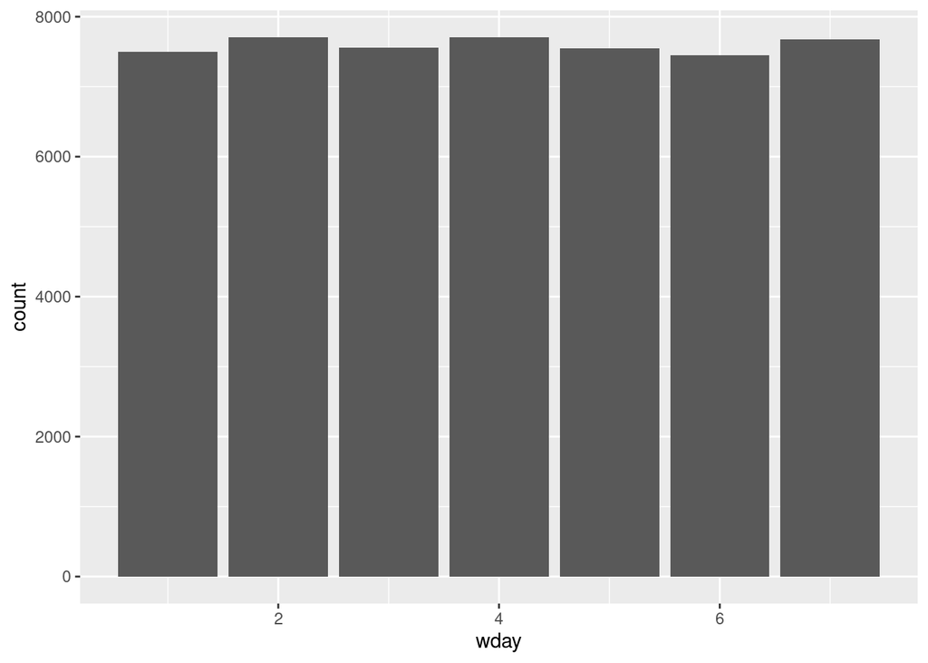

```r
#admission week day
ad_icu_combine %>%
  mutate(wday = wday(admittime), label = TRUE) %>%
  ggplot(aes(x = wday)) +
  geom_bar()
```

- admission hour (anything unusual?)

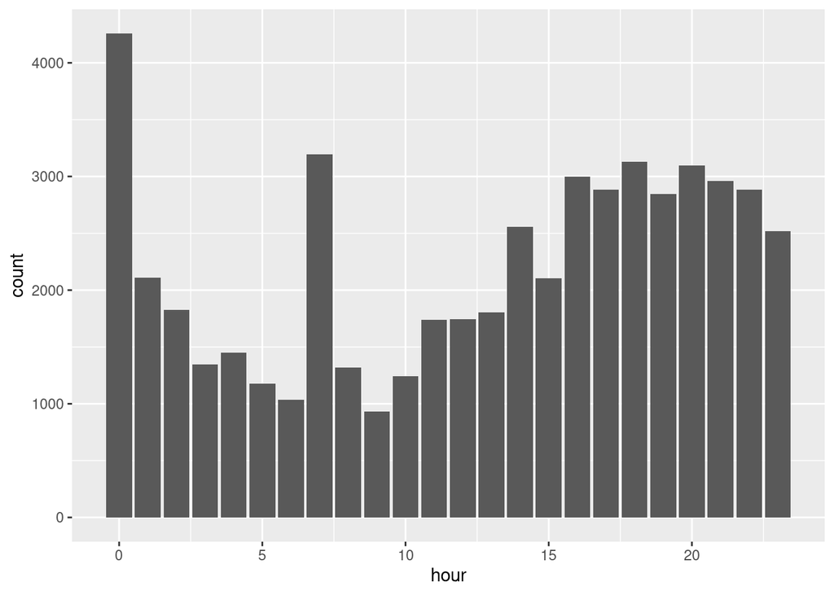

```r
#admission hour
ad_icu_combine %>%
  mutate(hour = hour(admittime), label = TRUE) %>%
  ggplot(aes(x = hour)) +
  geom_bar()
```

From the plot above, we can see the trend that the most frequent hour in a day that people got transferred to ICU is during the midnight (00:00 AM-01:00 AM). Moreover, the ICU cases from 15:00 PM to 00:00 AM tend to be higher than the cases number from 01:00 AM to 15:00 PM.

## Q4. `patients` data

Patient information is available in `patients.csv.gz`. See https://mimic.mit.edu/docs/iv/modules/core/patients/ for details of each field in this file. The first 10 lines are

```r
system(
  str_c(
    "zcat < ",
    shQuote(str_c(mimic_path, "/core/patients.csv.gz")),
    " | head"
    ),
  intern = TRUE
)
```

```
##  [1] "subject_id,gender,anchor_age,anchor_year,anchor_year_group,dod"
##  [2] "10000048,F,23,2126,2008 - 2010,"
##  [3] "10002723,F,0,2128,2017 - 2019,"
##  [4] "10003939,M,0,2184,2008 - 2010,"
##  [5] "10004222,M,0,2161,2014 - 2016,"
##  [6] "10005325,F,0,2154,2011 - 2013,"
##  [7] "10007338,F,0,2153,2017 - 2019,"
##  [8] "10008101,M,0,2142,2008 - 2010,"
##  [9] "10009872,F,0,2168,2014 - 2016,"
## [10] "10011333,F,0,2132,2014 - 2016,"
```

1. Import `patients.csv.gz` (https://mimic.mit.edu/docs/iv/modules/core/patients/) as a tibble `patients_tble` and only keep the patients who have a match in `icustays_tble` (according to `subject_id`).

**Solution:**

```r
patients_tble <- read_csv("/mnt/mimiciv/1.0/core/patients.csv.gz")
patient_icu_combine <-
  patients_tble %>%
  semi_join(icustays_tble, by = "subject_id")
patient_icu_combine
```

```
## # A tibble: 53,150 × 6
##    subject_id gender anchor_age anchor_year anchor_year_group dod
##         <dbl> <chr>       <dbl>       <dbl> <chr>             <date>
##  1   10018928 F              31        2125 2008 - 2010       NA
##  2   10076543 F              78        2187 2008 - 2010       NA
##  3   10098428 F              85        2119 2008 - 2010       NA
##  4   10127185 M              60        2141 2008 - 2010       NA
##  5   10148710 M              67        2137 2008 - 2010       NA
##  6   10156486 F              75        2124 2017 - 2019       NA
##  7   10159585 M              59        2146 2008 - 2010       2154-04-16
##  8   10171525 F              27        2115 2014 - 2016       NA
##  9   10196360 M              57        2118 2011 - 2013       NA
## 10   10227823 M              45        2156 2014 - 2016       NA
## # … with 53,140 more rows
```

2. Summarize variables `gender` and `anchor_age`, and explain any patterns you see.

**Solution:**

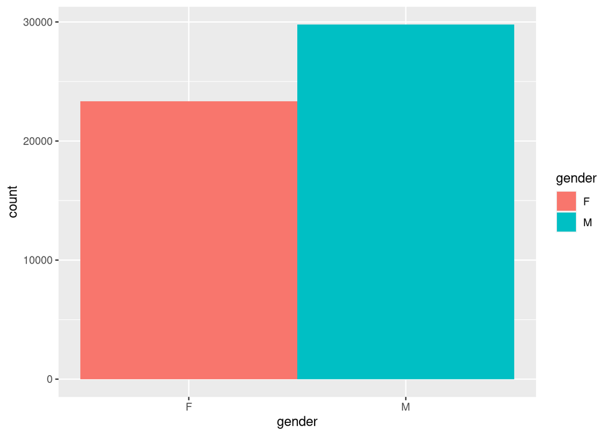

```r
#gender
patient_icu_combine %>%
  ggplot(mapping = aes(x = gender, fill = gender)) +
  geom_bar(width = 1)
```

From the plot above, we can tell that the number of male is larger than female.

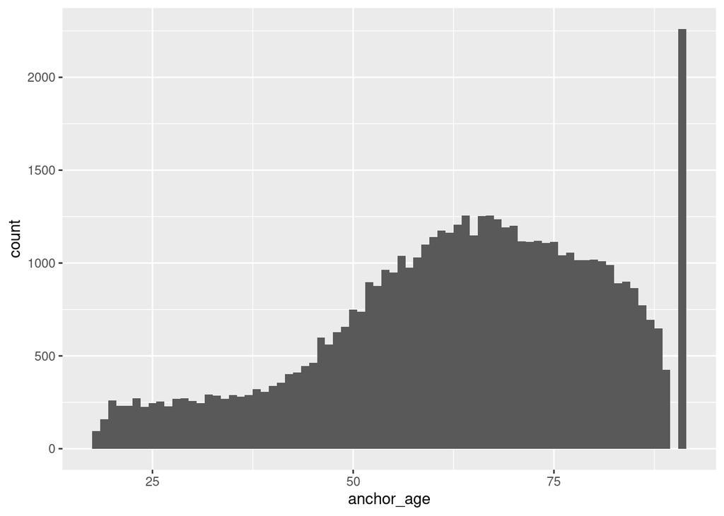

```r
#anchor_age
patient_icu_combine %>%
  ggplot(mapping = aes(x = anchor_age, fill = anchor_age)) +
  geom_bar(width = 1)
```

```r
summary(patient_icu_combine$anchor_age)
```

```
##    Min. 1st Qu.  Median    Mean 3rd Qu.    Max.
##   18.00   53.00   65.00   63.51   77.00   91.00
```

From the plot above, we can tell that the maximum age for the patient is 91, which is also the most frequent age in this data. That’s weird because it is not possible that the number of most frequent age appear in the extreme value. I believe that there must be an age transformation for anchor_age. On the other hand, the distribution of the anchor age is left skewed with the median anchor age is 65.

## Q5. Lab results

`labevents.csv.gz` (https://mimic.mit.edu/docs/iv/modules/hosp/labevents/) contains all laboratory measurements for patients. The first 10 lines are

```r
system(
  str_c(
    "zcat < ",
    shQuote(str_c(mimic_path, "/hosp/labevents.csv.gz")),
    " | head"
    ),
  intern = TRUE
)
```

```
##  [1] "labevent_id,subject_id,hadm_id,specimen_id,itemid,charttime,storetime,value,valuenum,valueuom,ref_range_lower,ref_range_upper,flag,priority,comments"
##  [2] "670,10000048,,6448755,51484,2126-11-22 19:20:00,2126-11-22 20:07:00,150,150,mg/dL,,,,STAT,"
##  [3] "673,10000048,,6448755,51491,2126-11-22 19:20:00,2126-11-22 20:07:00,6.5,6.5,units,5,8,,STAT,"
##  [4] "675,10000048,,6448755,51498,2126-11-22 19:20:00,2126-11-22 20:07:00,1.029,1.029, ,1.001,1.035,,STAT,"
##  [5] "683,10000048,,82729055,50861,2126-11-22 20:45:00,2126-11-23 00:55:00,39,39,IU/L,0,40,,STAT,"
##  [6] "684,10000048,,82729055,50862,2126-11-22 20:45:00,2126-11-23 00:55:00,4.7,4.7,g/dL,3.4,4.8,,STAT,"
##  [7] "685,10000048,,82729055,50863,2126-11-22 20:45:00,2126-11-23 00:55:00,45,45,IU/L,39,117,,STAT,"
##  [8] "686,10000048,,82729055,50868,2126-11-22 20:45:00,2126-11-22 21:32:00,13,13,mEq/L,8,20,,STAT,"
##  [9] "687,10000048,,82729055,50878,2126-11-22 20:45:00,2126-11-23 00:55:00,28,28,IU/L,0,40,,STAT,"
## [10] "688,10000048,,82729055,50882,2126-11-22 20:45:00,2126-11-22 21:32:00,26,26,mEq/L,22,32,,STAT,"
```

`d_labitems.csv.gz` is the dictionary of lab measurements.

```r
system(
  str_c(
    "zcat < ",
    shQuote(str_c(mimic_path, "/hosp/d_labitems.csv.gz")),
    " | head"
    ),
  intern = TRUE
)
```

```
##  [1] "itemid,label,fluid,category,loinc_code"
##  [2] "51905, ,Other Body Fluid,Chemistry,"
##  [3] "51532,11-Deoxycorticosterone,Blood,Chemistry,"
##  [4] "51957,17-Hydroxycorticosteroids,Urine,Chemistry,"
##  [5] "51958,\"17-Ketosteroids, Urine\",Urine,Chemistry,"
##  [6] "52068,24 Hr,Blood,Hematology,"
##  [7] "51066,24 hr Calcium,Urine,Chemistry,"
##  [8] "51067,24 hr Creatinine,Urine,Chemistry,"
##  [9] "51068,24 hr Protein,Urine,Chemistry,"
## [10] "50853,25-OH Vitamin D,Blood,Chemistry,"
```

1. Find how many rows are in `labevents.csv.gz`.

**Solution:**

```r
system(
  str_c(
    "zcat < ",
    shQuote(str_c(mimic_path, "/hosp/labevents.csv.gz")),
    " | tail -n +2 | wc -l"
    ),
  intern = TRUE
)
```

```
## [1] "122103667"
```

There are 122,103,667 rows are in `labevents.csv.gz`.

2. We are interested in the lab measurements of creatinine (50912), potassium (50971), sodium (50983), chloride (50902), bicarbonate (50882), hematocrit (51221), white blood cell count (51301), glucose (50931), magnesium (50960), and calcium (50893). Retrieve a subset of `labevents.csv.gz` only containing these items for the patients in `icustays_tble` as a tibble `labevents_tble`.

   Hint: `labevents.csv.gz` is a data file too big to be read in by the `read_csv` function in its default setting. Utilize the `col_select` and `lazy` options in the `read_csv` function to reduce the memory burden.

**Solution:**

```r
labevents <-
  read_csv("/mnt/mimiciv/1.0/hosp/labevents_filtered_itemid.csv.gz", lazy =T)
value_interest <- c("50912", "50971", "50983", "50902", "50882", "51221",
                    "51301", "50931", "50960", "50893")
labevents_tble <-
  labevents %>%
  semi_join(icustays_tble, by = c("subject_id")) %>%
  filter(itemid %in% value_interest)

labevents_tble
```

```
## # A tibble: 16,698,462 × 4
##    subject_id itemid charttime           valuenum
##         <dbl>  <dbl> <dttm>                 <dbl>
##  1   10003700  50882 2162-11-15 17:00:00     27
##  2   10003700  50902 2162-11-15 17:00:00    103
##  3   10003700  50912 2162-11-15 17:00:00      1
##  4   10003700  50931 2162-11-15 17:00:00     93
##  5   10003700  50971 2162-11-15 17:00:00      4.1
##  6   10003700  50983 2162-11-15 17:00:00    141
##  7   10003700  51221 2162-11-15 17:00:00     40
##  8   10003700  51301 2162-11-15 17:00:00      6.7
##  9   10003700  51221 2165-04-24 03:40:00     41
## 10   10003700  51301 2165-04-24 03:40:00      5.8
## # … with 16,698,452 more rows
```

3. Further restrict `labevents_tble` to the first lab measurement during the ICU stay.

**Solution:**

```r
labevents_tble <- labevents_tble %>%
                  #pull in intime
                  left_join(select(icustays_tble,
                                   intime,
                                   subject_id), by = "subject_id") %>%
                  #only keep first lab measurement after intime
                  filter(charttime >= intime) %>%
                  #for each subject*item
                  group_by(subject_id, itemid) %>%
                  #sort time and output first
                  arrange(charttime, .by_group = T) %>%
                  slice_head(n = 1) %>%
                  ungroup()
labevents_tble
```

```
## # A tibble: 523,252 × 5
##    subject_id itemid charttime           valuenum intime
##         <dbl>  <dbl> <dttm>                 <dbl> <dttm>
##  1   10000032  50882 2180-07-23 21:45:00     21   2180-07-23 14:00:00
##  2   10000032  50893 2180-07-23 21:45:00      9.3 2180-07-23 14:00:00
##  3   10000032  50902 2180-07-23 21:45:00    102   2180-07-23 14:00:00
##  4   10000032  50912 2180-07-23 21:45:00      0.5 2180-07-23 14:00:00
##  5   10000032  50931 2180-07-23 21:45:00    115   2180-07-23 14:00:00
##  6   10000032  50960 2180-07-23 21:45:00      2.3 2180-07-23 14:00:00
##  7   10000032  50971 2180-07-23 21:45:00      4.7 2180-07-23 14:00:00
##  8   10000032  50983 2180-07-23 21:45:00    132   2180-07-23 14:00:00
##  9   10000032  51221 2180-07-24 06:35:00     34.8 2180-07-23 14:00:00
## 10   10000032  51301 2180-07-24 06:35:00      4.1 2180-07-23 14:00:00
## # … with 523,242 more rows
```

4. Summarize the lab measurements by appropriate numerics and graphics.

**Solution:**

```r
labevents_tble %>%
  group_by(itemid) %>%
  summarise(count = n(),
            mean = mean(valuenum, na.rm = T),
            sd = sd(valuenum, na.rm = T),
            range = max(valuenum, na.rm = T) - min(valuenum, na.rm = T))
```

```
## # A tibble: 10 × 5
##    itemid count   mean     sd  range
##     <dbl> <int>  <dbl>  <dbl>  <dbl>
##  1  50882 52451  23.0   4.43    47
##  2  50893 51308   8.37  0.858   43
##  3  50902 52461 104.    6.28    95
##  4  50912 52470   1.31  1.46    36.9
##  5  50931 52443 141.   71.6   2433
##  6  50960 52293   2.00  0.501   47
##  7  50971 52468   4.18  0.700   12.2
##  8  50983 52467 139.    4.95    88
##  9  51221 52456  32.8   6.51    64.3
## 10  51301 52435  12.0  10.2    572.
```

```r
group_lab <- labevents_tble %>%
             mutate(Id= row_number()) %>%
             spread(key = itemid, value = valuenum)

#rename column creatinine (50912), potassium (50971), sodium (50983), chloride (50902), bicarbonate (50882), hematocrit (51221), white blood cell count (51301), glucose (50931), magnesium (50960), and calcium (50893)

group_lab <- group_lab %>%
             rename(creatinine = `50912`,
                    potassium = `50971`,
                    sodium = `50983`,
                    chloride = `50902`,
                    bicarbonate = `50882`,
                    hematocrit = `51221`,
                    WBC_count = `51301`,
                    glucose = `50931`,
                    magnesium = `50960`,
                    calcium = `50893`)

library(gridExtra)
```

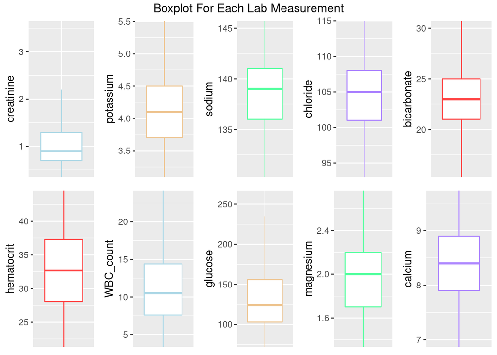

```r
s1 <-
  group_lab %>%
  ggplot(mapping = aes(x = " ",
                       y = creatinine)) +
         geom_boxplot(color = "lightblue", outlier.shape = NA) +
         coord_cartesian(ylim = quantile(group_lab$creatinine,
                                         c(0.05, 0.95),
                                         na.rm = T)) +
         theme(axis.title.x=element_blank(),
               axis.text.x=element_blank(),
               axis.ticks.x=element_blank())

s2 <-
  group_lab %>%
  ggplot(mapping = aes(x = " ",
                       y = potassium)) +
         geom_boxplot(color = "burlywood2", outlier.shape = NA) +
         coord_cartesian(ylim =
                          quantile(group_lab$potassium,
                                         c(0.05, 0.95),
                                         na.rm = T)) +
         theme(axis.title.x=element_blank(),
               axis.text.x=element_blank(),
               axis.ticks.x=element_blank())
s3 <-
  group_lab %>%
  ggplot(mapping = aes(x = " ",
                       y = sodium)) +
         geom_boxplot(color = "seagreen1", outlier.shape = NA) +
         coord_cartesian(ylim =
                      quantile(group_lab$sodium,
                                         c(0.05, 0.95),
                                         na.rm = T)) +
         theme(axis.title.x=element_blank(),
               axis.text.x=element_blank(),
               axis.ticks.x=element_blank())
s4 <-
  group_lab %>%
  ggplot(mapping = aes(x = " ",
                       y = chloride)) +
         geom_boxplot(color = "mediumpurple1", outlier.shape = NA) +
         coord_cartesian(ylim =
                          quantile(group_lab$chloride,
                                         c(0.05, 0.95),
                                         na.rm = T)) +
         theme(axis.title.x=element_blank(),
               axis.text.x=element_blank(),
               axis.ticks.x=element_blank())
s5 <-
  group_lab %>%
  ggplot(mapping = aes(x = " ",
                       y = bicarbonate)) +
         geom_boxplot(color = "brown1", outlier.shape = NA) +
         coord_cartesian(ylim =
                          quantile(group_lab$bicarbonate,
                                         c(0.05, 0.95),
                                         na.rm = T)) +
         theme(axis.title.x=element_blank(),
               axis.text.x=element_blank(),
               axis.ticks.x=element_blank())

s6 <-
  group_lab %>%
  ggplot(mapping = aes(x = " ",
                       y = hematocrit)) +
         geom_boxplot(color = "brown1", outlier.shape = NA) +
         coord_cartesian(ylim =
                          quantile(group_lab$hematocrit,
                                         c(0.05, 0.95),
                                         na.rm = T)) +
         theme(axis.title.x=element_blank(),
               axis.text.x=element_blank(),
               axis.ticks.x=element_blank())

s7 <-
  group_lab %>%
  ggplot(mapping = aes(x = " ",
                       y = WBC_count)) +
         geom_boxplot(color = "lightblue", outlier.shape = NA) +
         coord_cartesian(ylim = quantile(group_lab$WBC_count,
                                         c(0.05, 0.95),
                                         na.rm = T)) +
         theme(axis.title.x=element_blank(),
               axis.text.x=element_blank(),
               axis.ticks.x=element_blank())
s8 <-
  group_lab %>%
  ggplot(mapping = aes(x = " ",
                       y = glucose)) +
         geom_boxplot(color = "burlywood2", outlier.shape = NA) +
         coord_cartesian(ylim =
                          quantile(group_lab$glucose,
                                         c(0.05, 0.95),
                                         na.rm = T)) +
         theme(axis.title.x=element_blank(),
               axis.text.x=element_blank(),
               axis.ticks.x=element_blank())
s9 <-
  group_lab %>%
  ggplot(mapping = aes(x = " ",
                       y = magnesium)) +
         geom_boxplot(color = "seagreen1", outlier.shape = NA) +
         coord_cartesian(ylim =
                      quantile(group_lab$magnesium,
                                         c(0.05, 0.95),
                                         na.rm = T)) +
         theme(axis.title.x=element_blank(),
               axis.text.x=element_blank(),
               axis.ticks.x=element_blank())
s10 <-
  group_lab %>%
  ggplot(mapping = aes(x = " ",
                       y = calcium)) +
         geom_boxplot(color = "mediumpurple1", outlier.shape = NA) +
         coord_cartesian(ylim =
                          quantile(group_lab$calcium,
                                         c(0.05, 0.95),
                                         na.rm = T)) +
         theme(axis.title.x=element_blank(),
               axis.text.x=element_blank(),
               axis.ticks.x=element_blank())

grid.arrange(s1, s2, s3, s4, s5, s6, s7, s8, s9, s10, ncol=5, nrow = 2,
             top = "Boxplot For Each Lab Measurement")
```

## Q6. Vitals from charted events

`chartevents.csv.gz` (https://mimic.mit.edu/docs/iv/modules/icu/chartevents/) contains all the charted data available for a patient. During their ICU stay, the primary repository of a patient’s information is their electronic chart. The `itemid` variable indicates a single measurement type in the database. The `value` variable is the value measured for `itemid`. The first 10 lines of `chartevents.csv.gz` are

```r
system(
  str_c(
    "zcat < ",
    shQuote(str_c(mimic_path, "/icu/chartevents.csv.gz")),
    " | head"),
  intern = TRUE
)
```

```
##  [1] "subject_id,hadm_id,stay_id,charttime,storetime,itemid,value,valuenum,valueuom,warning"
##  [2] "10003700,28623837,30600691,2165-04-24 05:10:00,2165-04-24 05:11:00,228236,0,0,,0"
##  [3] "10003700,28623837,30600691,2165-04-24 05:12:00,2165-04-24 05:14:00,225067,0,0,,0"
##  [4] "10003700,28623837,30600691,2165-04-24 05:12:00,2165-04-24 05:14:00,225070,1,1,,0"
##  [5] "10003700,28623837,30600691,2165-04-24 05:12:00,2165-04-24 05:14:00,225076,1,1,,0"
##  [6] "10003700,28623837,30600691,2165-04-24 05:12:00,2165-04-24 05:14:00,225078,1,1,,0"
##  [7] "10003700,28623837,30600691,2165-04-24 05:12:00,2165-04-24 05:14:00,225086,1,1,,0"
##  [8] "10003700,28623837,30600691,2165-04-24 05:12:00,2165-04-24 05:14:00,225091,1,1,,0"
##  [9] "10003700,28623837,30600691,2165-04-24 05:12:00,2165-04-24 05:14:00,225103,1,1,,0"
## [10] "10003700,28623837,30600691,2165-04-24 05:12:00,2165-04-24 05:14:00,225106,1,1,,0"
```

`d_items.csv.gz` (https://mimic.mit.edu/docs/iv/modules/icu/d_items/) is the dictionary for the `itemid` in `chartevents.csv.gz`.

```r
system(
  str_c(
    "zcat < ",
    shQuote(str_c(mimic_path, "/icu/d_items.csv.gz")),
    " | head"),
  intern = TRUE
)
```

```
##  [1] "itemid,label,abbreviation,linksto,category,unitname,param_type,lownormalvalue,highnormalvalue"
##  [2] "220003,ICU Admission date,ICU Admission date,datetimeevents,ADT,,Date and time,,"
##  [3] "220045,Heart Rate,HR,chartevents,Routine Vital Signs,bpm,Numeric,,"
##  [4] "220046,Heart rate Alarm - High,HR Alarm - High,chartevents,Alarms,bpm,Numeric,,"
##  [5] "220047,Heart Rate Alarm - Low,HR Alarm - Low,chartevents,Alarms,bpm,Numeric,,"
##  [6] "220048,Heart Rhythm,Heart Rhythm,chartevents,Routine Vital Signs,,Text,,"
##  [7] "220050,Arterial Blood Pressure systolic,ABPs,chartevents,Routine Vital Signs,mmHg,Numeric,90,140"
##  [8] "220051,Arterial Blood Pressure diastolic,ABPd,chartevents,Routine Vital Signs,mmHg,Numeric,60,90"
##  [9] "220052,Arterial Blood Pressure mean,ABPm,chartevents,Routine Vital Signs,mmHg,Numeric,,"
## [10] "220056,Arterial Blood Pressure Alarm - Low,ABP Alarm - Low,chartevents,Alarms,mmHg,Numeric,,"
```

1. We are interested in the vitals for ICU patients: heart rate (220045), mean non-invasive blood pressure (220181), systolic non-invasive blood pressure (220179), body temperature in Fahrenheit (223761), and respiratory rate (220210). Retrieve a subset of `chartevents.csv.gz` only containing these items for the patients in `icustays_tble` as a tibble `chartevents_tble`.

**Solution:**

```r
chartevents <-
  read_csv("/mnt/mimiciv/1.0/icu/chartevents_filtered_itemid.csv.gz")
vitals_interest <- c("220045", "220181", "220179", "223761", "220210")

chartevents_tble <-
  chartevents %>%
  semi_join(icustays_tble, by = "subject_id") %>%
  filter(itemid %in% vitals_interest)

chartevents_tble
```

```
## # A tibble: 23,679,058 × 6
##    subject_id  hadm_id  stay_id charttime           itemid valuenum
##         <dbl>    <dbl>    <dbl> <dttm>               <dbl>    <dbl>
##  1   10003700 28623837 30600691 2165-04-24 05:28:00 220179    152
##  2   10003700 28623837 30600691 2165-04-24 05:28:00 220181    110
##  3   10003700 28623837 30600691 2165-04-24 05:30:00 220045     65
##  4   10003700 28623837 30600691 2165-04-24 05:30:00 220210     14
##  5   10003700 28623837 30600691 2165-04-24 05:38:00 223761     97.6
##  6   10003700 28623837 30600691 2165-04-24 06:00:00 220045     56
##  7   10003700 28623837 30600691 2165-04-24 06:00:00 220179    126
##  8   10003700 28623837 30600691 2165-04-24 06:00:00 220181     88
##  9   10003700 28623837 30600691 2165-04-24 06:00:00 220210     14
## 10   10003700 28623837 30600691 2165-04-24 06:09:00 220045     55
## # … with 23,679,048 more rows
```

2. Further restrict `chartevents_tble` to the first vital measurement during the ICU stay.

**Solution:**

```r
chartevents_tble <- chartevents_tble %>%
                    #pull in intime
                    left_join(select(icustays_tble,
                                     intime,
                                     subject_id), by = "subject_id") %>%
                    #only keep first lab measurement after intime
                    filter(charttime >= intime) %>%
                    #for each subject*item
                    group_by(subject_id, itemid) %>%
                    #sort time and output first
                    arrange(charttime, .by_group = T) %>%
                    slice_head(n = 1) %>%
                    ungroup()
chartevents_tble
```

```
## # A tibble: 263,847 × 7
##    subject_id  hadm_id  stay_id charttime           itemid valuenum
##         <dbl>    <dbl>    <dbl> <dttm>               <dbl>    <dbl>
##  1   10000032 29079034 39553978 2180-07-23 14:12:00 220045     91
##  2   10000032 29079034 39553978 2180-07-23 14:11:00 220179     84
##  3   10000032 29079034 39553978 2180-07-23 14:11:00 220181     56
##  4   10000032 29079034 39553978 2180-07-23 14:12:00 220210     24
##  5   10000032 29079034 39553978 2180-07-23 14:00:00 223761     98.7
##  6   10000980 26913865 39765666 2189-06-27 08:56:00 220045     77
##  7   10000980 26913865 39765666 2189-06-27 08:55:00 220179    150
##  8   10000980 26913865 39765666 2189-06-27 08:55:00 220181     92
##  9   10000980 26913865 39765666 2189-06-27 08:54:00 220210     23
## 10   10000980 26913865 39765666 2189-06-27 09:07:00 223761     98
## # … with 263,837 more rows, and 1 more variable: intime <dttm>
```

3. Summarize these vital measurements by appropriate numerics and graphics.

**Solution:**

```r
chartevents_tble %>%
  group_by(itemid) %>%
  summarise(count = n(),
            mean = mean(valuenum, na.rm = T),
            sd = sd(valuenum, na.rm = T),
            range = max(valuenum, na.rm = T) - min(valuenum, na.rm = T))
```

```
## # A tibble: 5 × 5
##   itemid count  mean     sd  range
##    <dbl> <int> <dbl>  <dbl>  <dbl>
## 1 220045 53149  87.5  20.2     941
## 2 220179 52638 124.   58.2   12262
## 3 220181 52617  87.4 805.   140119
## 4 220210 53113  18.7   6.21    180
## 5 223761 52330  98.0   3.34    106
```

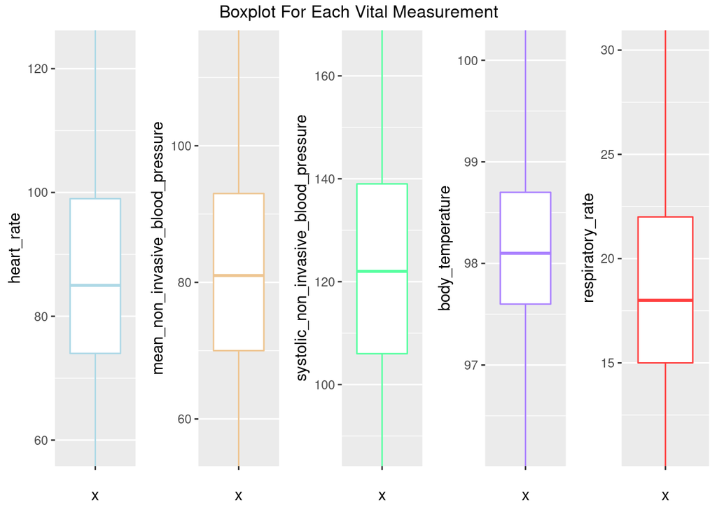

```r
group_chart <- chartevents_tble %>%
               spread(key = itemid, value = valuenum)

#rename column heart rate (220045), mean non-invasive blood pressure (220181), systolic non-invasive blood pressure (220179), body temperature in Fahrenheit (223761), and respiratory rate (220210)

group_chart <- group_chart %>%
               rename(heart_rate = `220045`,
                      mean_non_invasive_blood_pressure = `220181`,
                      systolic_non_invasive_blood_pressure = `220179`,
                      body_temperature = `223761`,
                      respiratory_rate = `220210`)

library(gridExtra)

p1 <-
  group_chart %>%
  ggplot(mapping = aes(x = " ",
                       y = heart_rate)) +
         geom_boxplot(color = "lightblue", outlier.shape = NA) +
         coord_cartesian(ylim = quantile(group_chart$heart_rate,
                                         c(0.05, 0.95),
                                         na.rm = T))

p2 <-
  group_chart %>%
  ggplot(mapping = aes(x = " ",
                       y = mean_non_invasive_blood_pressure)) +
         geom_boxplot(color = "burlywood2", outlier.shape = NA) +
         coord_cartesian(ylim =
                          quantile(group_chart$mean_non_invasive_blood_pressure,
                                         c(0.05, 0.95),
                                         na.rm = T))
p3 <-
  group_chart %>%
  ggplot(mapping = aes(x = " ",
                       y = systolic_non_invasive_blood_pressure)) +
         geom_boxplot(color = "seagreen1", outlier.shape = NA) +
         coord_cartesian(ylim =
                      quantile(group_chart$systolic_non_invasive_blood_pressure,
                                         c(0.05, 0.95),
                                         na.rm = T))
p4 <-
  group_chart %>%
  ggplot(mapping = aes(x = " ",
                       y = body_temperature)) +
         geom_boxplot(color = "mediumpurple1", outlier.shape = NA) +
         coord_cartesian(ylim =
                          quantile(group_chart$body_temperature,
                                         c(0.05, 0.95),
                                         na.rm = T))
p5 <-
  group_chart %>%
  ggplot(mapping = aes(x = " ",
                       y = respiratory_rate)) +
         geom_boxplot(color = "brown1", outlier.shape = NA) +
         coord_cartesian(ylim =
                          quantile(group_chart$respiratory_rate,
                                         c(0.05, 0.95),
                                         na.rm = T))

grid.arrange(p1, p2, p3, p4, p5, ncol=5, nrow = 1,
             top = "Boxplot For Each Vital Measurement")
```

## Q7. Putting things together

Let us create a tibble `mimic_icu_cohort` for all ICU stays, where rows are

- first ICU stay of each unique adult (age at admission > 18)

and columns contain at least following variables

- all variables in `icustays.csv.gz`
- all variables in `admission.csv.gz`
- all variables in `patients.csv.gz`
- first lab measurements during ICU stay
- first vital measurements during ICU stay
- an indicator variable `thirty_day_mort` whether the patient died within 30 days of hospital admission (30 day mortality)

**Solution:**

```r
#combine with patients.csv.gz
patient_icu_combine <-
  icustays_tble %>%
  left_join(patients_tble, by = "subject_id")

#combine with admission.csv.gz
ad_pa_icu_combine <-
  admissions_tble %>%
  left_join(patient_icu_combine, by = c("subject_id", "hadm_id"))

#rename itemid and valuenum for lab measurement
labevents_tble <- labevents_tble %>%
  rename(lab_item = itemid,
         lab_value = valuenum)

#first lab measurements during ICU stay
ad_pa_icu_lab_combine <-
  labevents_tble %>%
  subset(select = -charttime) %>%
  left_join(ad_pa_icu_combine, by = c("subject_id", "intime")) %>%
  spread(key = lab_item, value = lab_value)

#rename itemid and valuenum for vital measurement
chartevents_tble <- chartevents_tble %>%
  rename(vital_item = itemid,
         vital_value = valuenum)

#first vital measurements during ICU stay
mimic_icu_cohort <-
  chartevents_tble %>%
  subset(select = -charttime) %>%
  left_join(ad_pa_icu_lab_combine, by = c("subject_id",
                                           "intime",
                                           "hadm_id",
                                           "stay_id")) %>%
    spread(key = vital_item, value = vital_value)

#(age at admission > 18)
#an indicator variable `thirty_day_mort`
mimic_icu_cohort <-
  mimic_icu_cohort %>%
  mutate(age_hadm = anchor_age + year(admittime) - anchor_year) %>%
  filter(age_hadm > 18) %>%
  mutate(thirty_day_mort = ifelse(as.Date(deathtime) - as.Date(admittime) > 30,
                                  1,0))

#rename the lab_item and vital_item
mimic_icu_cohort <-
  mimic_icu_cohort %>%
  rename(heart_rate = `220045`,
         mean_non_invasive_blood_pressure = `220181`,
         systolic_non_invasive_blood_pressure = `220179`,
         body_temperature = `223761`,
         respiratory_rate = `220210`,
         creatinine = `50912`,
         potassium = `50971`,
         sodium = `50983`,
         chloride = `50902`,
         bicarbonate = `50882`,
         hematocrit = `51221`,
         WBC_count = `51301`,
         glucose = `50931`,
         magnesium = `50960`,
         calcium = `50893`)

mimic_icu_cohort
```

```
## # A tibble: 52,449 × 43
##    subject_id  hadm_id  stay_id intime              admittime
##         <dbl>    <dbl>    <dbl> <dttm>              <dttm>
##  1   10000032 29079034 39553978 2180-07-23 14:00:00 2180-07-23 12:35:00
##  2   10000980 26913865 39765666 2189-06-27 08:42:00 2189-06-27 07:38:00
##  3   10001217 24597018 37067082 2157-11-20 19:18:02 2157-11-18 22:56:00
##  4   10001725 25563031 31205490 2110-04-11 15:52:22 2110-04-11 15:08:00
##  5   10001884 26184834 37510196 2131-01-11 04:20:05 2131-01-07 20:39:00
##  6   10002013 23581541 39060235 2160-05-18 10:00:53 2160-05-18 07:45:00
##  7   10002155 23822395 33685454 2129-08-04 12:45:00 2129-08-04 12:44:00
##  8   10002223 22494570 39638202 2158-01-15 08:01:49 2158-01-15 08:00:00
##  9   10002348 22725460 32610785 2112-11-30 23:24:00 2112-11-30 22:22:00
## 10   10002428 28662225 33987268 2156-04-12 16:24:18 2156-04-12 14:16:00
## # … with 52,439 more rows, and 38 more variables: dischtime <dttm>,
## #   deathtime <dttm>, admission_type <chr>, admission_location <chr>,
## #   discharge_location <chr>, insurance <chr>, language <chr>,
## #   marital_status <chr>, ethnicity <chr>, edregtime <dttm>, edouttime <dttm>,
## #   hospital_expire_flag <dbl>, first_careunit <chr>, last_careunit <chr>,
## #   outtime <dttm>, los <dbl>, gender <chr>, anchor_age <dbl>,
## #   anchor_year <dbl>, anchor_year_group <chr>, dod <date>, …
```

## Q8. Exploratory data analysis (EDA)

Summarize following information using appropriate numerics or graphs.

- `thirty_day_mort` vs demographic variables (ethnicity, language, insurance, marital_status, gender, age at hospital admission)

**Solution:**

```r
#ethnicity
mimic_icu_cohort %>%
  group_by(thirty_day_mort, ethnicity) %>%
  summarise(count = n()) %>%
  spread(key = ethnicity , value = count) %>%
  rowwise() %>%
  mutate(total = sum(c_across("AMERICAN INDIAN/ALASKA NATIVE":"WHITE"),
                 na.rm = T)) %>%
  mutate_at(vars("AMERICAN INDIAN/ALASKA NATIVE":"WHITE"),
            funs(round(./ total, digits = 3)*100)) %>%
  print(width = Inf)
```

```
## # A tibble: 3 × 10
## # Rowwise:  thirty_day_mort
##   thirty_day_mort `AMERICAN INDIAN/ALASKA NATIVE` ASIAN `BLACK/AFRICAN AMERICAN`
##             <dbl>                           <dbl> <dbl>                    <dbl>
## 1               0                             0.1   3                        7.6
## 2               1                            NA     2.7                      7.1
## 3              NA                             0.2   2.9                      9.4
##   `HISPANIC/LATINO` OTHER `UNABLE TO OBTAIN` UNKNOWN WHITE total
##               <dbl> <dbl>              <dbl>   <dbl> <dbl> <int>
## 1               2.2   4.2                2.2    22    58.7  4832
## 2               3.1   4.7                2.7    15.3  64.4   295
## 3               3.6   4.8                1.3     9.7  68   47322
```

**Solution:**

From the table I made below, it shows that the proportion of insurance in those three groups of thirty_day_mort. As we can see that the value of patient who died within 30 days of hospital admission have higher proportion on choosing Medicaid (12.2%) compare to other two groups.

```r
#insurance
mimic_icu_cohort %>%
  group_by(thirty_day_mort, insurance) %>%
  summarise(count = n()) %>%
  spread(key = insurance , value = count) %>%
  rowwise() %>%
  mutate(total = sum(c_across("Medicaid":"Other"),
                 na.rm = T)) %>%
  mutate_at(vars("Medicaid":"Other"),
            funs(round(./ total, digits = 3)*100)) %>%
  print(width = Inf)
```

```
## # A tibble: 3 × 5
## # Rowwise:  thirty_day_mort
##   thirty_day_mort Medicaid Medicare Other total
##             <dbl>    <dbl>    <dbl> <dbl> <int>
## 1               0      5.8     52.6  41.6  4832
## 2               1     12.2     43.7  44.1   295
## 3              NA      7.3     41.9  50.8 47322
```

**Solution:**

From the table I made below, it shows that the proportion of marital_status in those three groups of thirty_day_mort. As we can see that the value of patient who died after 30 days of hospital admission (thirty_day_mort = 0) have different pattern compare to other two groups, which included higher proportion on WIDOWED, NA and lower proportion on SINGLE and MARRIED.

```r
#marital_status
mimic_icu_cohort %>%
  group_by(thirty_day_mort, marital_status) %>%
  summarise(count = n()) %>%
  spread(key = marital_status , value = count) %>%
  rowwise() %>%
  mutate(total = sum(c_across("DIVORCED":"<NA>"),
                 na.rm = T)) %>%
  mutate_at(vars("DIVORCED":"<NA>"),
            funs(round(./ total, digits = 3)*100)) %>%
  print(width = Inf)
```

```
## # A tibble: 3 × 7
## # Rowwise:  thirty_day_mort
##   thirty_day_mort DIVORCED MARRIED SINGLE WIDOWED `<NA>` total
##             <dbl>    <dbl>   <dbl>  <dbl>   <dbl>  <dbl> <int>
## 1               0      5.8    39.3   19.5    16     19.4  4832
## 2               1      7.8    45.1   28.8     8.8    9.5   295
## 3              NA      7.1    46.2   27.5    11.8    7.5 47322
```

**Solution:**

```r
#gender
mimic_icu_cohort %>%
  group_by(thirty_day_mort, gender) %>%
  summarise(count = n()) %>%
  spread(key = gender , value = count) %>%
  rowwise() %>%
  mutate(total = sum(c_across("F":"M"),
                 na.rm = T)) %>%
  mutate_at(vars("F":"M"),
            funs(round(./ total, digits = 3)*100)) %>%
  print(width = Inf)
```

```
## # A tibble: 3 × 4
## # Rowwise:  thirty_day_mort
##   thirty_day_mort     F     M total
##             <dbl> <dbl> <dbl> <int>
## 1               0  46.1  53.9  4832
## 2               1  46.1  53.9   295
## 3              NA  43.7  56.3 47322
```

**Solution:**

From the graphic I made below, it shows that the boxplot of age at hospital admission in those three groups of thirty_day_mort. Although we can see that the value of age at hospital admission of patient who died after 30 days of hospital admission (thirty_day_mort = 0) have higher mean, I believe that they still have similar pattern within each group.

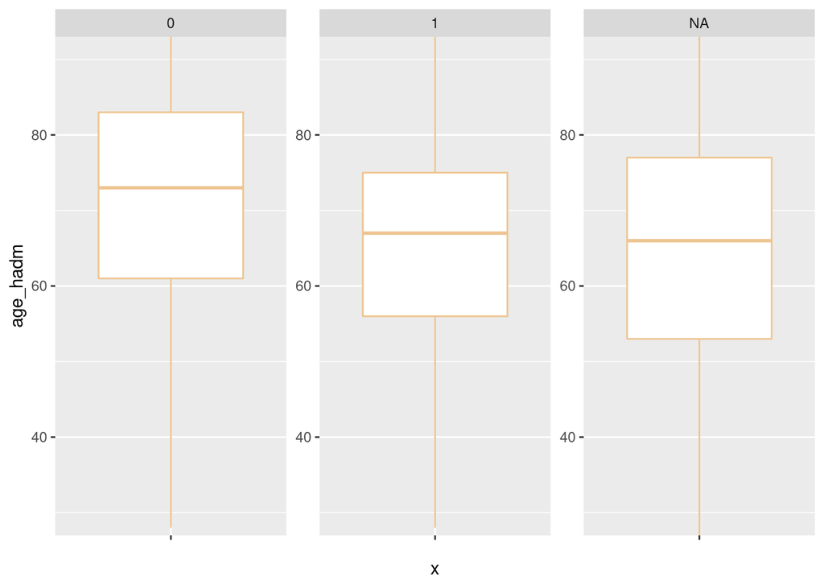

```r
#age at hospital admission
mimic_icu_cohort %>%
         ggplot(mapping = aes(x = " ", y = age_hadm)) +
         geom_boxplot(color = "burlywood2", outlier.shape = NA) +
         facet_wrap( ~ thirty_day_mort, scale="free") +
         coord_cartesian(ylim =
                         quantile(mimic_icu_cohort$age_hadm,
                                  c(0.05, 0.95),
                                  na.rm = T))
```

- `thirty_day_mort` vs first lab measurements

**Solution:**

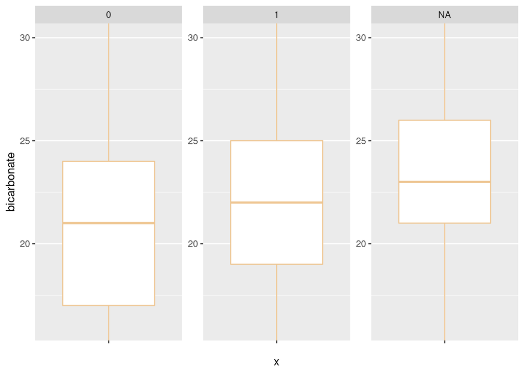

```r
#bicarbonate
mimic_icu_cohort %>%
         ggplot(mapping = aes(x = " ", y = bicarbonate)) +
         geom_boxplot(color = "burlywood2", outlier.shape = NA) +
         facet_wrap(~thirty_day_mort, scale="free") +
         coord_cartesian(ylim =
                         quantile(mimic_icu_cohort$bicarbonate,
                                  c(0.05, 0.95),
                                  na.rm = T))
```

**Solution:**

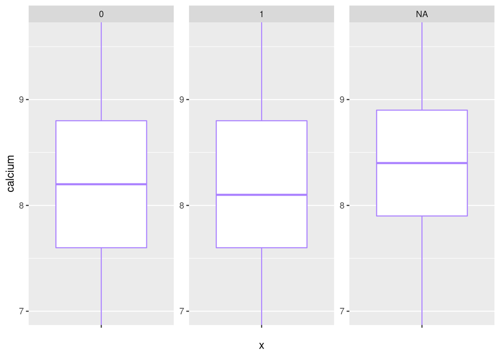

```r
#calcium
mimic_icu_cohort %>%
         ggplot(mapping = aes(x = " ", y = calcium)) +
         geom_boxplot(color = "mediumpurple1", outlier.shape = NA) +
         facet_wrap(~thirty_day_mort, scale="free") +
         coord_cartesian(ylim =
                         quantile(mimic_icu_cohort$calcium,
                                  c(0.05, 0.95),
                                  na.rm = T))
```

**Solution:**

From the graphic I made below, it shows that the boxplot of first lab measurements on chloride in those three groups of thirty_day_mort. We can see that the value of first lab measurements on chloride of patient who died after 30 days of hospital admission (thirty_day_mort = 0) have same mean, Q1 and Q3 as thirty_day_mort = 1.

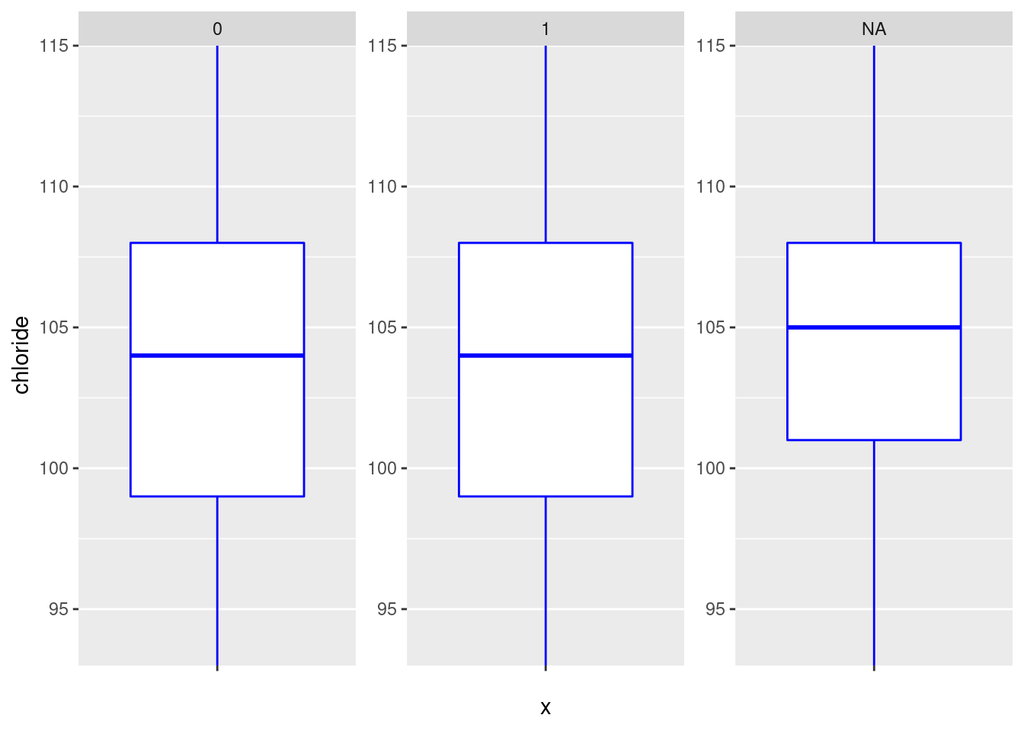

```r
#chloride
mimic_icu_cohort %>%
         ggplot(mapping = aes(x = " ", y = chloride)) +
         geom_boxplot(color = "blue", outlier.shape = NA) +
         facet_wrap( ~ thirty_day_mort, scale="free") +
         coord_cartesian(ylim =
                         quantile(mimic_icu_cohort$chloride,
                                  c(0.05, 0.95),
                                  na.rm = T))
```

**Solution:**

From the graphic I made below, it shows that the boxplot of first lab measurements on creatinine in those three groups of thirty_day_mort. We can see that the value of first lab measurements on creatinine of patient who don’t died (thirty_day_mort = NA) have lowest mean, Q1 and Q3 compare to thirty_day_mort = 0 and 1.

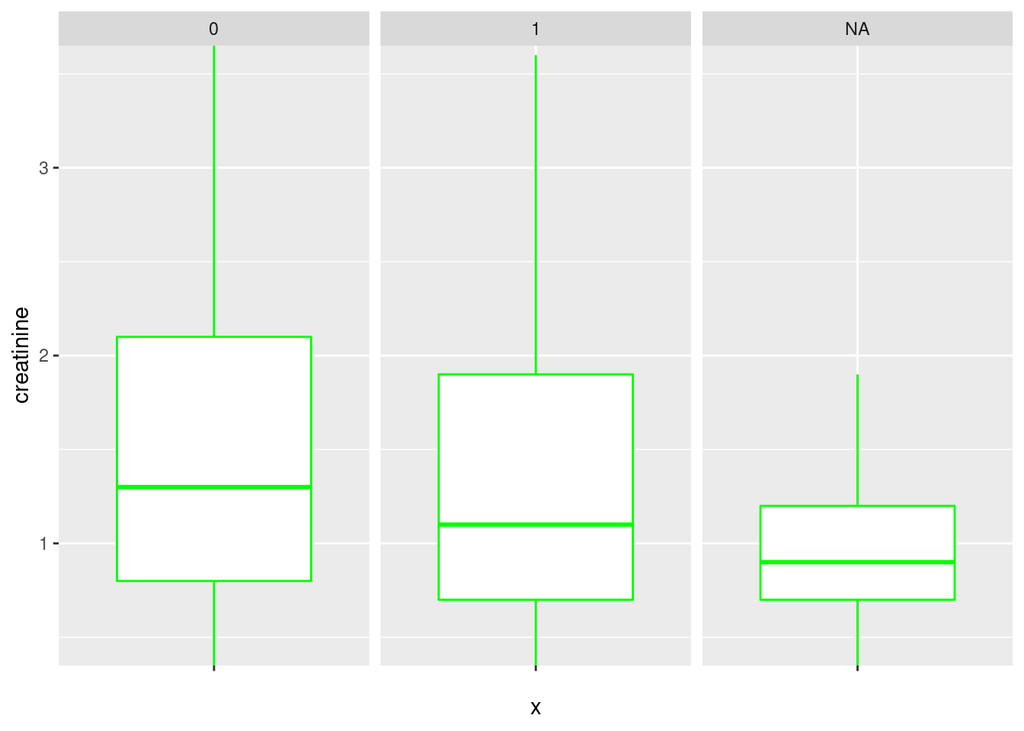

```r
#creatinine
mimic_icu_cohort %>%
         ggplot(mapping = aes(x = " ", y = creatinine)) +
         geom_boxplot(color = "green", outlier.shape = NA) +
         facet_wrap(~thirty_day_mort, scale="fixed") +
         coord_cartesian(ylim =
                         quantile(mimic_icu_cohort$creatinine,
                                  c(0.05, 0.95),
                                  na.rm = T))
```

**Solution:**

From the graphic I made below, it shows that the boxplot of first lab measurements on glucose in those three groups of thirty_day_mort. We can see that the value of first lab measurements on glucose of patient who don’t died (thirty_day_mort = NA) have lowest mean, Q1 and Q3 compare to thirty_day_mort = 0 and 1.

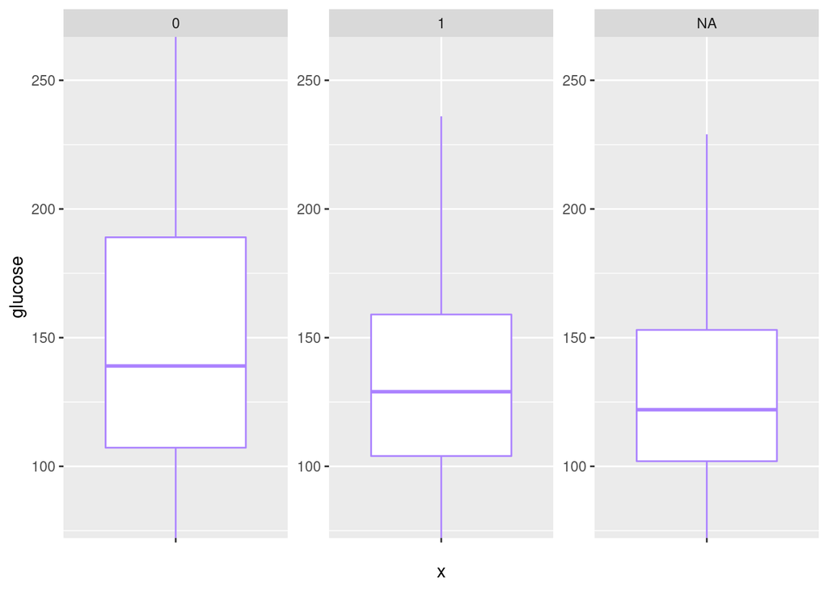

```r
#glucose
mimic_icu_cohort %>%
         ggplot(mapping = aes(x = " ", y = glucose)) +
         geom_boxplot(color = "mediumpurple1", outlier.shape = NA) +
         facet_wrap(~thirty_day_mort, scale="free") +
         coord_cartesian(ylim =
                         quantile(mimic_icu_cohort$glucose,
                                  c(0.05, 0.95),
                                  na.rm = T))
```

**Solution:**

From the graphic I made below, it shows that the boxplot of first lab measurements on magnesium in those three groups of thirty_day_mort. We can see that the value of first lab measurements on magnesium of patient who don’t died (thirty_day_mort = NA) have same pattern compare to thirty_day_mort = 0 and 1.

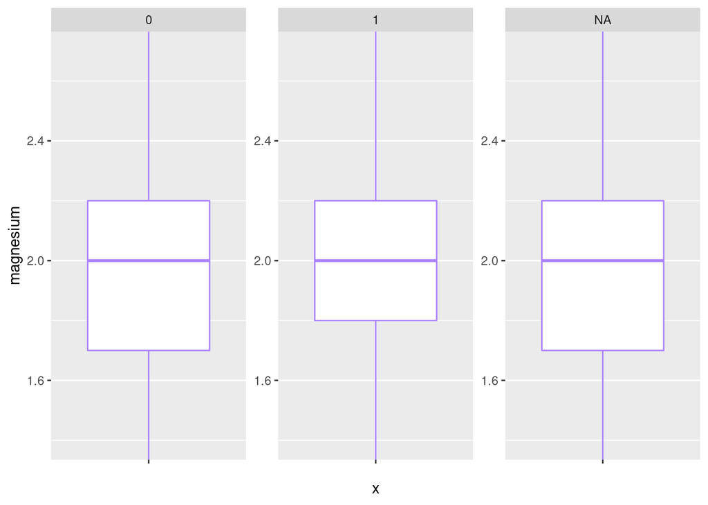

```r
#magnesium
mimic_icu_cohort %>%
         ggplot(mapping = aes(x = " ", y = magnesium)) +
         geom_boxplot(color = "mediumpurple1", outlier.shape = NA) +
         facet_wrap(~thirty_day_mort, scale="free") +
         coord_cartesian(ylim =
                         quantile(mimic_icu_cohort$magnesium,
                                  c(0.05, 0.95),
                                  na.rm = T))
```

**Solution:**

From the graphic I made below, it shows that the boxplot of first lab measurements on potassium in those three groups of thirty_day_mort. We can see that the value of first lab measurements on potassium of patient who don’t died (thirty_day_mort = NA) have same pattern compare to thirty_day_mort = 0 and 1.

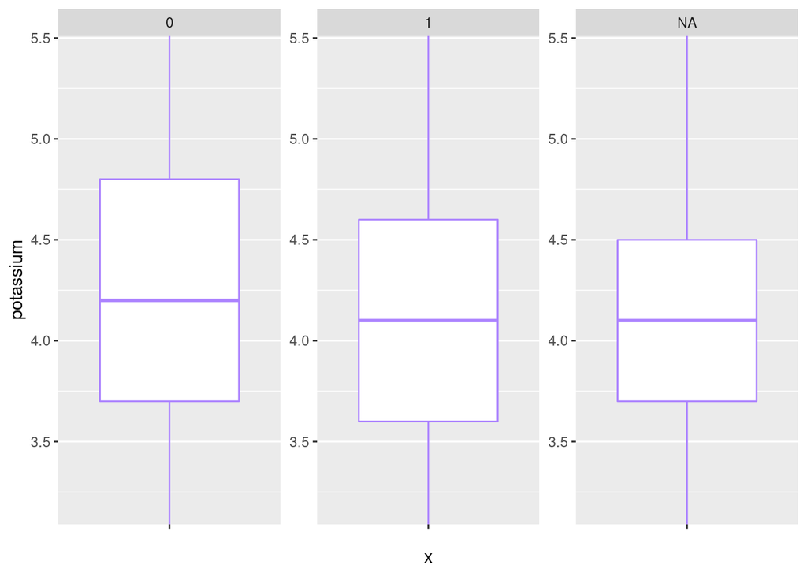

```r
#potassium
mimic_icu_cohort %>%
         ggplot(mapping = aes(x = " ", y = potassium)) +
         geom_boxplot(color = "mediumpurple1", outlier.shape = NA) +
         facet_wrap(~thirty_day_mort, scale="free") +
         coord_cartesian(ylim =
                         quantile(mimic_icu_cohort$potassium,
                                  c(0.05, 0.95),
                                  na.rm = T))
```

**Solution:**

From the graphic I made below, it shows that the boxplot of first lab measurements on sodium in those three groups of thirty_day_mort. We can see that the value of first lab measurements on sodium of patient who don’t died (thirty_day_mort = NA) have same pattern compare to thirty_day_mort = 0 and 1.

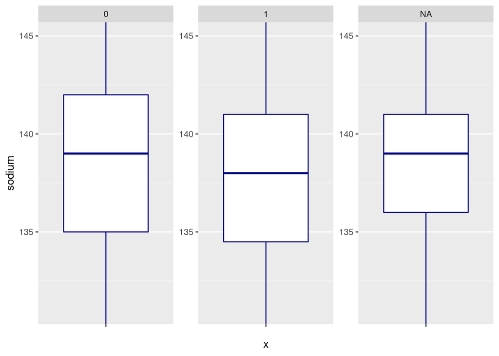

```r
#sodium
mimic_icu_cohort %>%
         ggplot(mapping = aes(x = " ", y = sodium)) +
         geom_boxplot(color = "navy blue", outlier.shape = NA) +
         facet_wrap(~thirty_day_mort, scale="free") +
         coord_cartesian(ylim =
                         quantile(mimic_icu_cohort$sodium,
                                  c(0.05, 0.95),
                                  na.rm = T))
```

**Solution:**

From the graphic I made below, it shows that the boxplot of first lab measurements on hematocrit in those three groups of thirty_day_mort. We can see that the value of first lab measurements on hematocrit of patient who died within 30 days of hospital admission (thirty_day_mort = 1) have lower mean, Q1, and Q3.

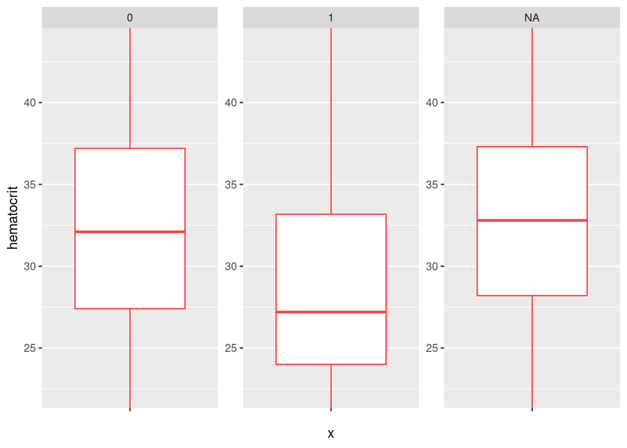

```r
#hematocrit
mimic_icu_cohort %>%
         ggplot(mapping = aes(x = " ", y = hematocrit)) +
         geom_boxplot(color = "brown1", outlier.shape = NA) +
         facet_wrap(~thirty_day_mort, scale="free") +
         coord_cartesian(ylim =
                         quantile(mimic_icu_cohort$hematocrit,
                                  c(0.05, 0.95),
                                  na.rm = T))
```

**Solution:**

From the graphic I made below, it shows that the boxplot of first lab measurements on WBC_count in those three groups of thirty_day_mort. We can see that the value of first lab measurements on WBC_count of patient who died after 30 days of hospital admission (thirty_day_mort = 0) have higher mean, Q1, and Q3.

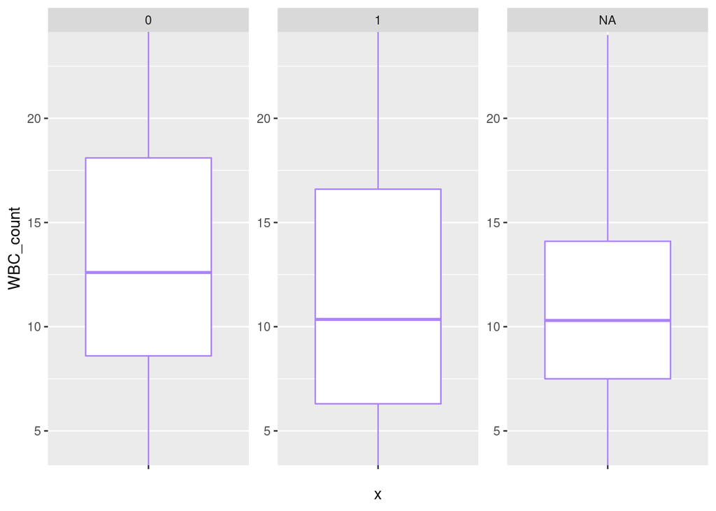

```r
#WBC_count
mimic_icu_cohort %>%
         ggplot(mapping = aes(x = " ", y = WBC_count)) +
         geom_boxplot(color = "mediumpurple1", outlier.shape = NA) +
         facet_wrap(~thirty_day_mort, scale="free") +
         coord_cartesian(ylim =
                         quantile(mimic_icu_cohort$WBC_count,
                                  c(0.05, 0.95),
                                  na.rm = T))
```

- `thirty_day_mort` vs first vital measurements

**Solution:**

From the graphic I made below, it shows that the boxplot of first vital measurements on heart_rate in those three groups of thirty_day_mort. We can see that the value of first vital measurements on heart_rate of patient who died within 30 days of hospital admission (thirty_day_mort = 1) have higher mean, Q1, and Q3.

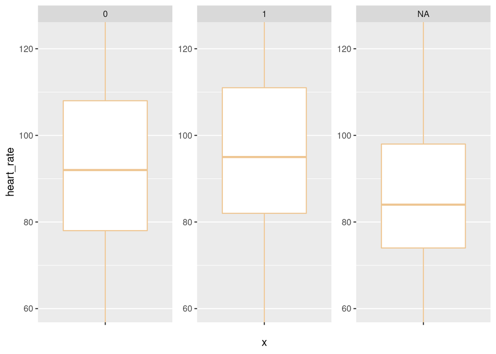

```r
#heart_rate
mimic_icu_cohort %>%
         ggplot(mapping = aes(x = " ", y = heart_rate)) +
         geom_boxplot(color = "burlywood2", outlier.shape = NA) +
         facet_wrap(~thirty_day_mort, scale="free") +
         coord_cartesian(ylim =
                         quantile(mimic_icu_cohort$heart_rate,
                                  c(0.05, 0.95),
                                  na.rm = T))
```

**Solution:**

From the graphic I made below, it shows that the boxplot of first vital measurements on mean_non_invasive_blood_pressure in those three groups of thirty_day_mort. We can see that the value of first vital measurements on mean_non_invasive_blood_pressure of patient who died within 30 days of hospital admission (thirty_day_mort = 1) have lower mean, Q1, and Q3.

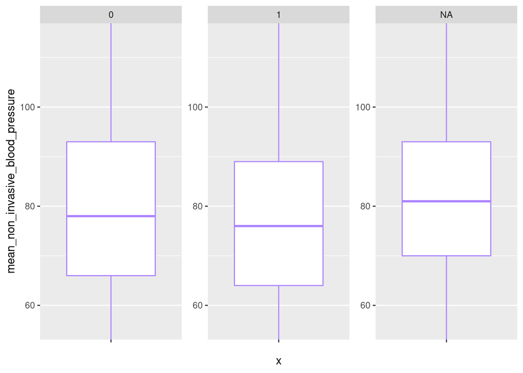

```r
#mean_non_invasive_blood_pressure
mimic_icu_cohort %>%
         ggplot(mapping = aes(x = " ", y = mean_non_invasive_blood_pressure)) +
         geom_boxplot(color = "mediumpurple1", outlier.shape = NA) +
         facet_wrap( ~ thirty_day_mort, scale="free") +
         coord_cartesian(ylim =
         quantile(mimic_icu_cohort$mean_non_invasive_blood_pressure,
                  c(0.05, 0.95),
                  na.rm = T))
```

**Solution:**

From the graphic I made below, it shows that the boxplot of first vital measurements on systolic_non_invasive_blood_pressure in those three groups of thirty_day_mort. We can see that the value of first vital measurements on systolic_non_invasive_blood_pressure of patient who died within 30 days of hospital admission (thirty_day_mort = 1) have lower mean, Q1, and Q3.

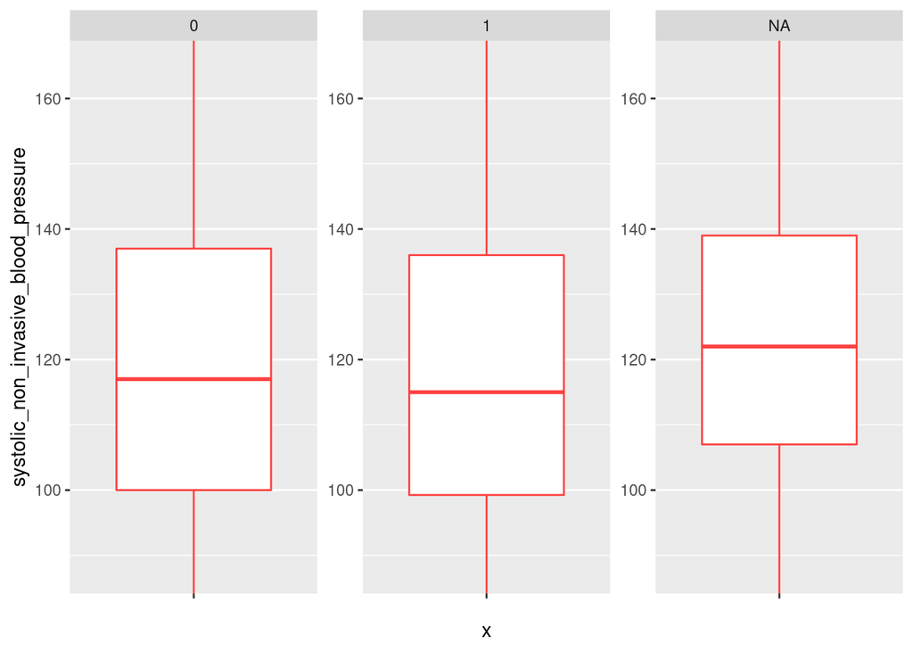

```r
#systolic_non_invasive_blood_pressure
mimic_icu_cohort %>%
         ggplot(mapping = aes(x = " ", y = systolic_non_invasive_blood_pressure)) +
         geom_boxplot(color = "brown1", outlier.shape = NA) +
         facet_wrap(~thirty_day_mort, scale="free") +
         coord_cartesian(ylim =
         quantile(mimic_icu_cohort$systolic_non_invasive_blood_pressure,
                  c(0.05, 0.95),
                  na.rm = T))
```

**Solution:**

From the graphic I made below, it shows that the boxplot of first vital measurements on body_temperture in those three groups of thirty_day_mort. We can see that the value of first vital measurements on body_temperture of patient who don’t died (thirty_day_mort = NA) have same pattern compare to thirty_day_mort = 0 and 1.

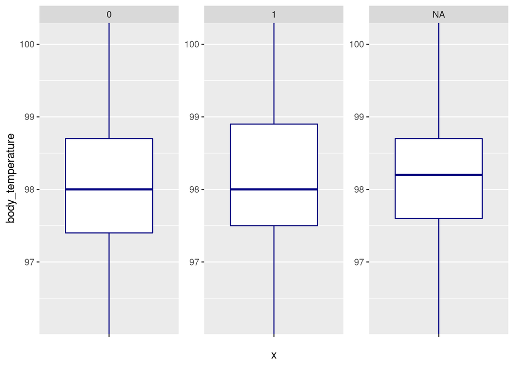

```r
#body_temperture
mimic_icu_cohort %>%
         ggplot(mapping = aes(x = " ", y = body_temperature)) +
         geom_boxplot(color = "navy blue", outlier.shape = NA) +
         facet_wrap(~thirty_day_mort, scale="free") +
         coord_cartesian(ylim =
                          quantile(mimic_icu_cohort$body_temperature,
                                   c(0.05, 0.95),
                                   na.rm = T))
```

**Solution:**

From the graphic I made below, it shows that the boxplot of first vital measurements on respiratory_rate in those three groups of thirty_day_mort. We can see that the value of first vital measurements on respiratory_rate of patient who don’t died (thirty_day_mort = NA) have lower mean, Q1 and Q3 compare to thirty_day_mort = 0 and 1.

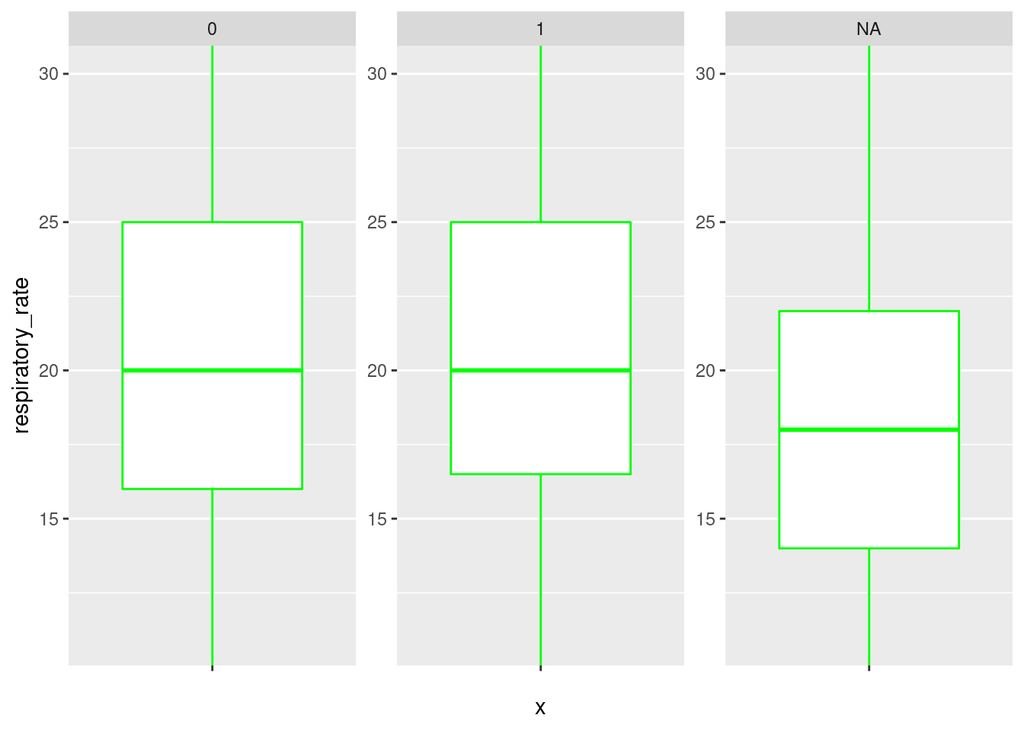

```r
#respiratory_rate
mimic_icu_cohort %>%
         ggplot(mapping = aes(x = " ", y = respiratory_rate)) +
         geom_boxplot(color = "green", outlier.shape = NA) +
         facet_wrap(~thirty_day_mort, scale="free") +
         coord_cartesian(ylim =
                          quantile(mimic_icu_cohort$respiratory_rate,
                                   c(0.05, 0.95),
                                   na.rm = T))
```

- `thirty_day_mort` vs first ICU unit

**Solution:**

From the above table I made, it shows that the proportion of first_careunit in those three groups of thirty_day_mort.

```r
#first_careunit
mimic_icu_cohort %>%
  group_by(thirty_day_mort, first_careunit) %>%
  summarise(count = n()) %>%
  spread(key = first_careunit , value = count) %>%
  rowwise() %>%
  mutate(total = sum(c_across("Cardiac Vascular Intensive Care Unit (CVICU)":
                                "Trauma SICU (TSICU)"),
                 na.rm = T)) %>%
  mutate_at(vars("Cardiac Vascular Intensive Care Unit (CVICU)":
                   "Trauma SICU (TSICU)"),
            funs(round(./ total, digits = 3)*100)) %>%
  print(width = Inf)
```

```
## # A tibble: 3 × 11
## # Rowwise:  thirty_day_mort
##   thirty_day_mort `Cardiac Vascular Intensive Care Unit (CVICU)`
##             <dbl>                                          <dbl>
## 1               0                                            5.1
## 2               1                                            8.5
## 3              NA                                           19.3
##   `Coronary Care Unit (CCU)` `Medical Intensive Care Unit (MICU)`
##                        <dbl>                                <dbl>
## 1                       14                                   27.2
## 2                        6.4                                 17.6
## 3                       11.3                                 18.4
##   `Medical/Surgical Intensive Care Unit (MICU/SICU)` `Neuro Intermediate`
##                                                <dbl>                <dbl>
## 1                                               20.5                  0.5
## 2                                               33.2                  0.7
## 3                                               16.1                  2.6
##   `Neuro Stepdown` `Neuro Surgical Intensive Care Unit (Neuro SICU)`
##              <dbl>                                             <dbl>
## 1              0.2                                               4.2
## 2              0.3                                               2
## 3              1.3                                               2.4
##   `Surgical Intensive Care Unit (SICU)` `Trauma SICU (TSICU)` total
##                                   <dbl>                 <dbl> <int>
## 1                                  16                    12.3  4832
## 2                                  21                    10.2   295
## 3                                  15.3                  13.1 47322
```